# Homework 1

Buhara Sayıl 19080415

**Question 1** With Markdown write a sentence that has one word in bold.

According to a new dataset about the global change of **climate**, Emissions increased sharply

**Question 2** With Markdown write a sentence that has one word in italic.

Water is an impact multiplier for *sustainability* and inextricably linked to climate change and the degradation of ecosystems

**Question 4** With Markdown write an unordered list with three items.

- Apple
- Strawberry
- Banana

**Question 5** With Markdown write an ordered list with three items.

1. Apple
2. Strawberry
3. Banana

**Question 6** With Markdown give a link to your favorite webpage.

[For see my favourite webpage, you can click](https://chat.openai.com/chat)

**Question 7** With Markdown add a cat picture.

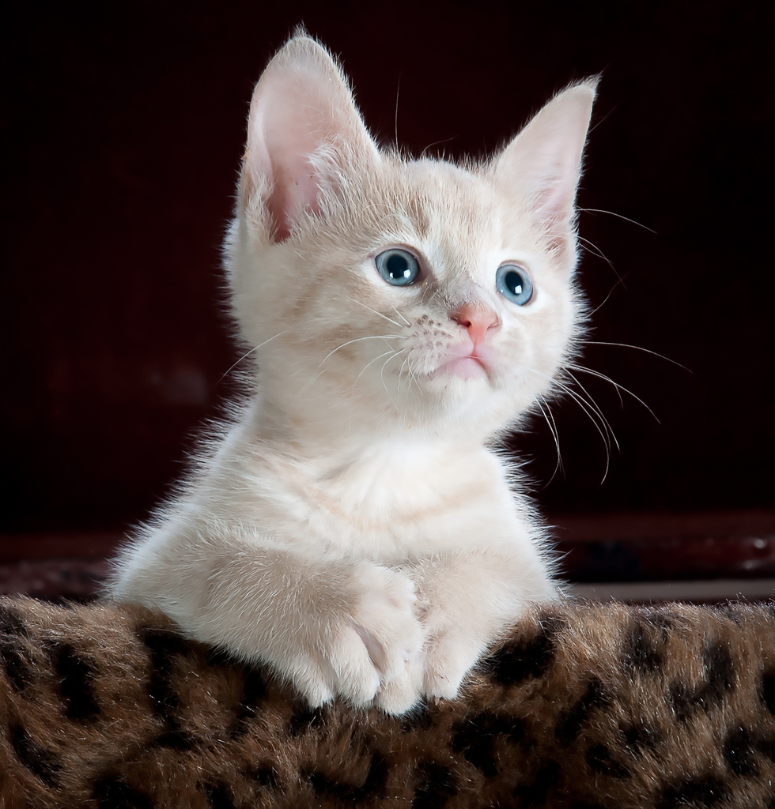

cat picture

**Question 8** With Rmarkdown insert a code chunk and give an example of a simple mathematical calculation in it.

```r
# Calculate the afor the sum of two exponential numbers
a <- 2^3
b <- 5^2
c <- a + b
c
```

```
## [1] 33
```

**Question 9** With $LaTeX$ write your favorite equation in block form.

$$E = mc^2$$

**Question 10** In a code chunk calculate 3 + 4.

```r
3+4
```

```
## [1] 7
```

for `3 + 4`